# Graphical Encoding

Author

Kris Sankaran

Published

September 1, 2026

Readings: [1 (Chapter 5.1 - 5.4 and 5.5.4)](https://search.library.wisc.edu/catalog/9910211448302121), [2 (optional)](https://rafalab.dfci.harvard.edu/dsbook/ggplot2.html).

[Code](https://github.com/krisrs1128/data_visualization_notes/blob/main/notes/01-graphical_encoding.qmd)

Items marked with $^\dagger$ will not be tested on exams.

1. If you are interested in data science, you’re probably already convinced that to understand something deeply it helps to measure. All the different data that we gather, the counts of different molecules in developing tissues, the spectral readouts from astronomical observatories, the likes and dislikes on a billions online videos…. these are attempts to make sense of a world that is too complicated to grasp all at once. All our advanced algorithms and statistical theories are forms of data compression, but designed for humans, not computers.
2. A common misconception is that to use data science methods you must be clever. That a trained data scientist can hear about a problem and data set and immediately conjure the appropriate methodology. In my experience this is not how things work. You don’t have to be clever, you only have to look at the data. A clear data of how the data look guides everything that happens later, all the modeling and inference. To know whether assumptions are reliable or conclusions can be trusted, we have to do some patient detective work. This class introduces you to the timeless concepts and modern methods of data visualization to help you do this detective work well.

### Graphical Encoding

3. Every plot has three parts. The first two are,
   - **Data**: The measurements that we want to visualize.
   - **Graphical marks**: The basic graphical elements in an image (e.g., circles, lines) that appear on the page.

   When we construct a data visualization, we are imprinting marks on a page. The properties of these marks that we can vary are called *visual channels*. For example, position and color are both channels that we can control in circle marks. This gives the third part,
   - **Graphical encoding**: The mapping from the data to the graphical marks’ visual channels
4. For example, the bar chart below shows country populations in 2000, from the gapminder dataset. The raw data are country names (categorical variable), their populations (numerical variable), and a country group giving the broader geographical region (categorical variable). The visual marks are colored rectangles. The graphical encoding is,
   - Bar length $\iff$ Population size.
   - `y`-axis position $\iff$ Country name. These have been sorted, so $y$-axisx position also encodes country rank.
   - `color` $\iff$ Country group.

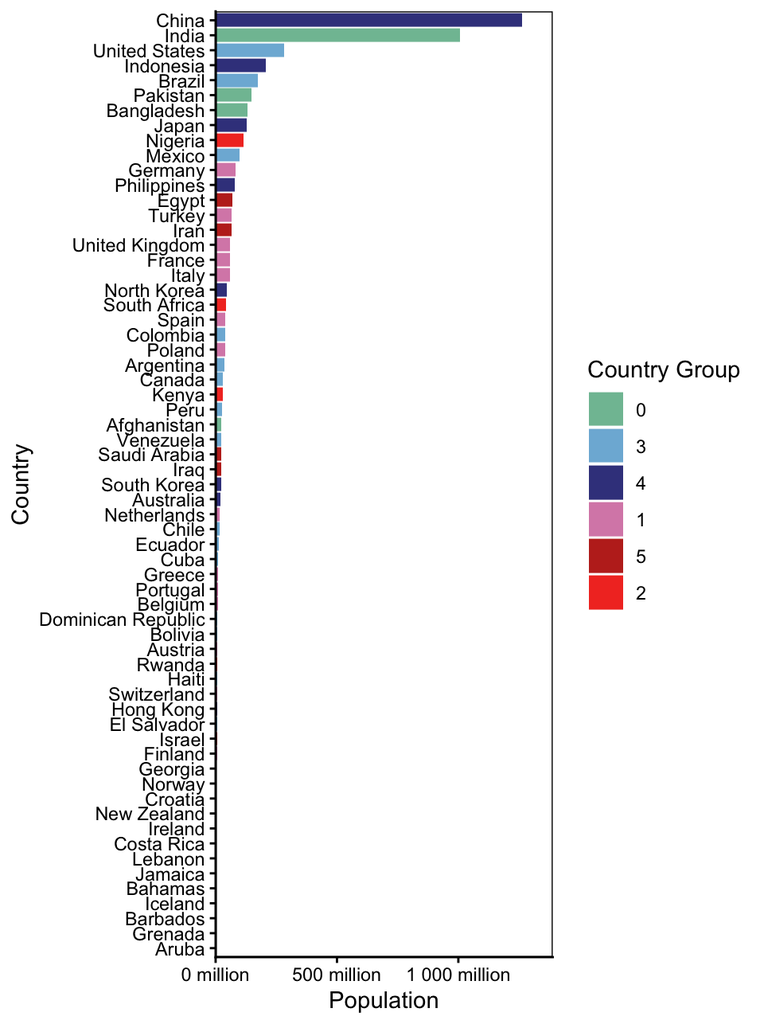

### Hierarchy of Encodings

5. How many times larger (in terms of area) is the circle on the right?

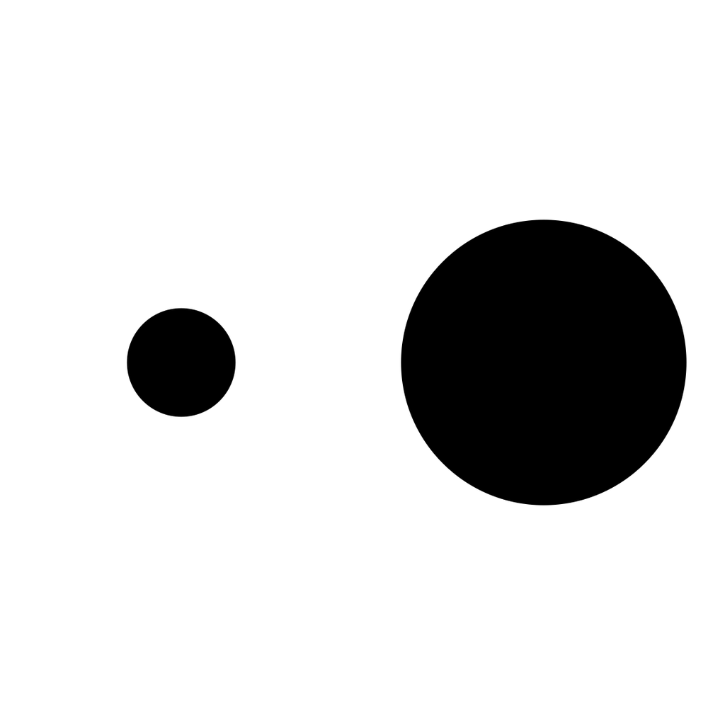

Same question, but for the relative heights of these two bars?

[figure not shown]

6. This is a special case of the hierarchy of encodings. Not all differences between visual channels can be compared with the same accuracy and speed. This is a limitation of human perception. In both laboratory and crowdsourcing experiments, the same orderings recur[^1].

You should remember the hierarchy below (at least, given a pair of channels, you should know which is more effective).

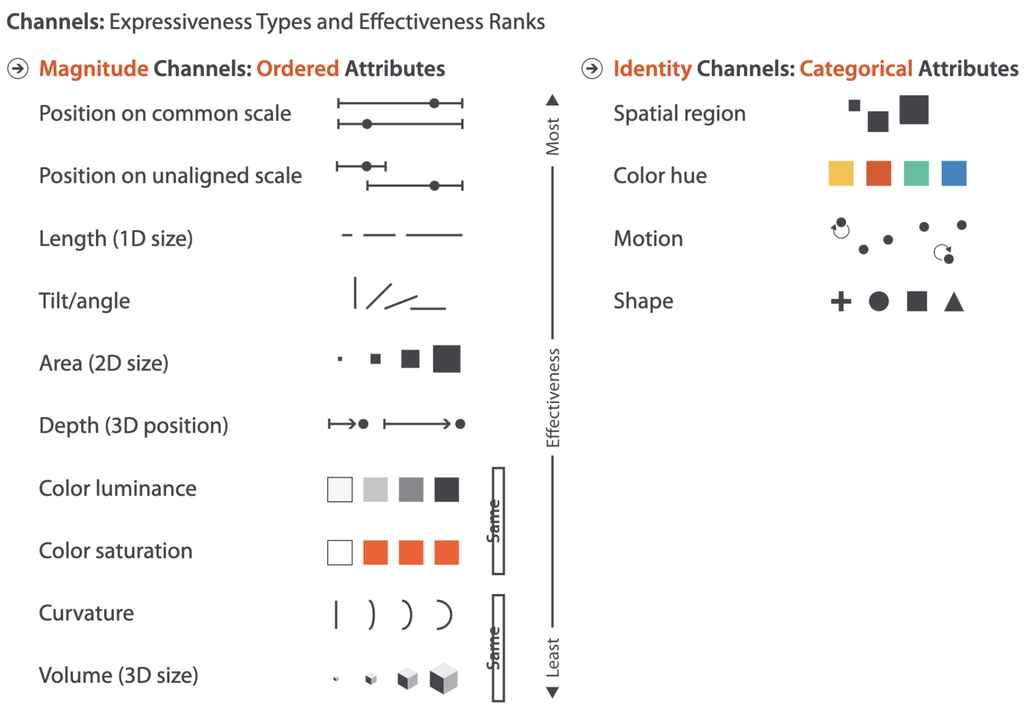

7. An implication of the hierarchy is the **Effectiveness Principle**. For any visualization task, we should use the top of the hierarchy for the most important comparisons. The best design always depends on the question. For example, to compare mileage with price across cars, use a scatterplot, but to analyze specific cars, use bar plots sorted by name, because we can then use position to look up car name.

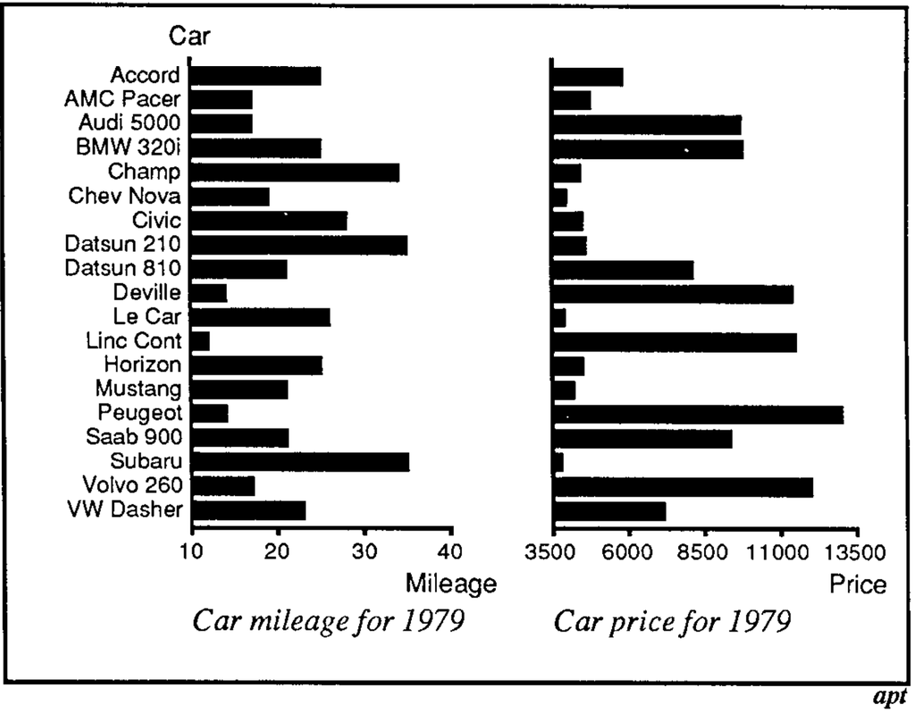

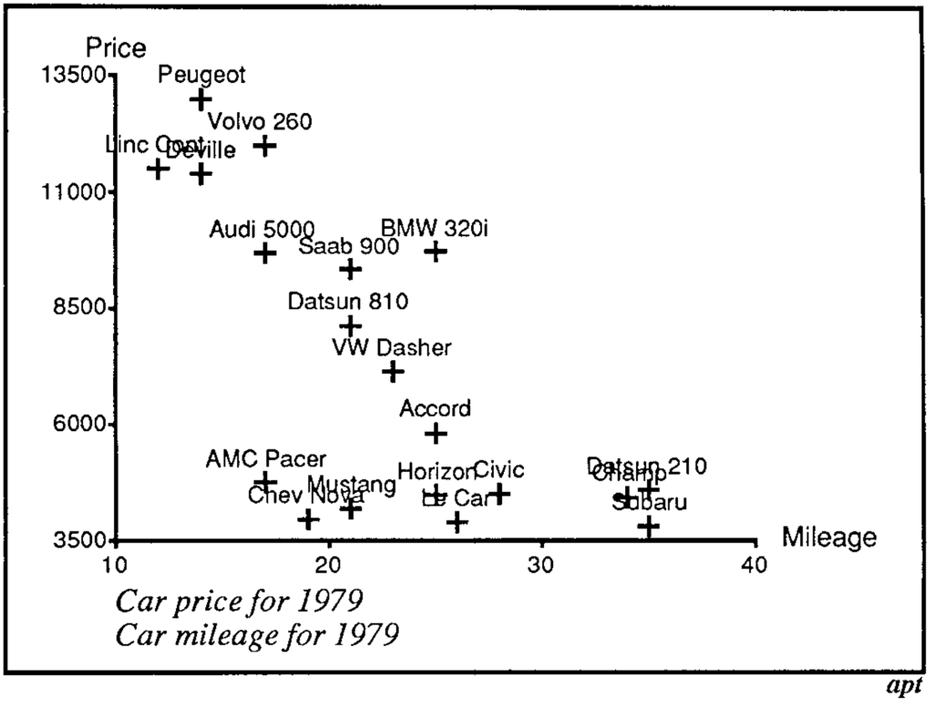

This gives a formal evaluation method. For a given task, one design is more *effective* than another if it lets the reader make the task’s comparisons more accurately.

8. Here is another exercise. How long does it take you to find the circle?

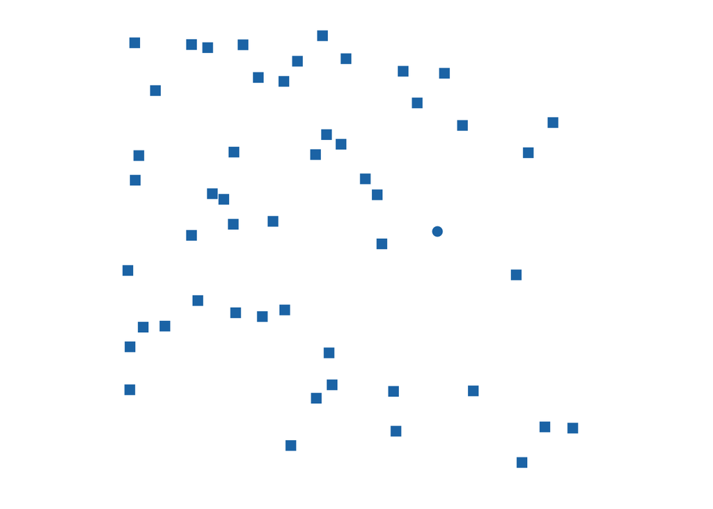

Okay, now compare with this.

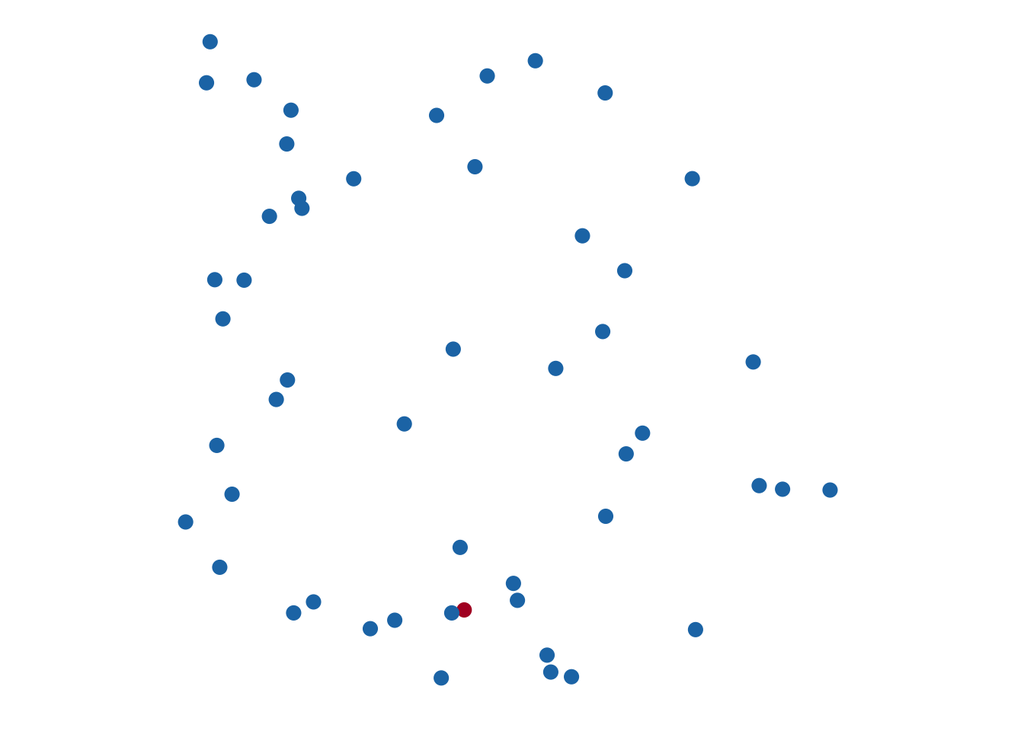

```r
popout_plot(n_blue_circles = 50, n_red_squares = 0)
```

Now, can you find the red circle?

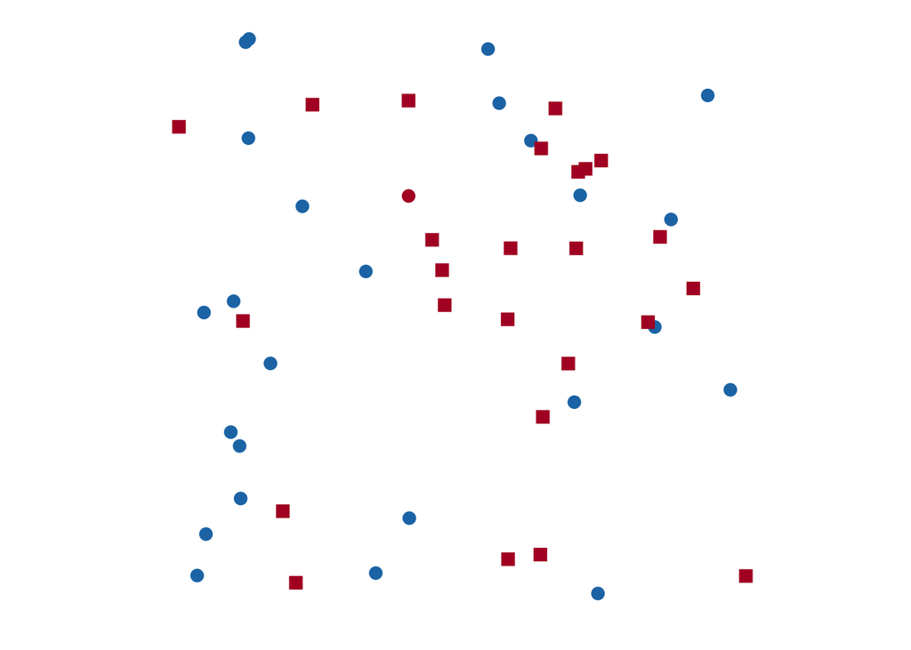

```r
popout_plot(n_blue_circles = 25, n_red_squares = 25)
```

9. What we have seen is the phenomenon called “visual popout” or, more formally, preattentive processing. Some properties in visual channels can be perceived immediately without any cognitive effort. Others (like shape in the example above) require us to deliberately scan over the visualization. Unfortunately, it’s not so straightforward to combine popout across channels. Once we have both red squares and circles, it’s no longer easy to find the red circle.

### Grammar of Graphics

10. The *Grammar of Graphics* is the idea that we can compose rich visualizations by combining a few basic building blocks. This is in contrast to systems with prespecified chart types, where the user is forced to pick from a limited dropdown menu of plots. The hope is to make visualization design feel more like ordinary language (hence *grammar*), even though each sentence is just a combination of words, we’re able to express infinite meanings.
11. We will use two implementations of the grammar of graphics. `ggplot2` is a twenty year old R package that is very widely used for static plots. `mosaic vgplot` is newer and built for interactivity. We’ll see how both handle data, marks, and encodings.

**`ggplot2`**

12. Let’s use the grammar of graphics to construct this plot.

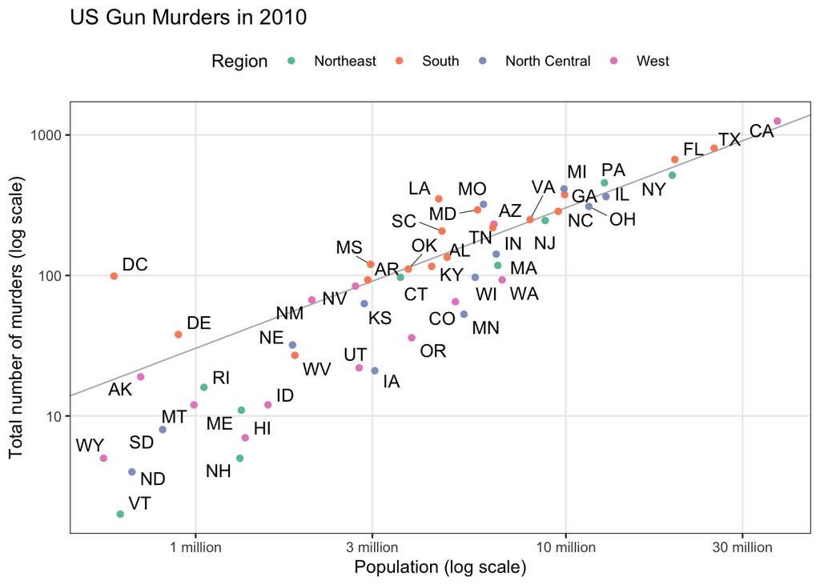

13. Data: The first argument to `ggplot()` must be a data.frame where each row is an observation and each column is an attribute describing the observation. Each mark that you see on a ggplot figure – a line, a point, a rectangle, … – started as a row within an R `data.frame`. The visual channels of the mark are determined by the column values.

```r
data(murders)
head(murders)
```

```
       state abb region population total
1    Alabama  AL  South    4779736   135
2     Alaska  AK   West     710231    19
3    Arizona  AZ   West    6392017   232
4   Arkansas  AR  South    2915918    93
5 California  CA   West   37253956  1257
6   Colorado  CO   West    5029196    65
```

14. Marks: The words in the grammar of graphics are the geometry layers, called “geoms.” We can associate each row of a data frame with points, lines, rectangles, etc., by referring to the appropriate geom. A typical plot will compose a chain of layers on top of a dataset,

> ggplot(data) + [layer 1] + [layer 2] + …

For example, by deconstructing the plot above, we would expect to have point and text layers. For now, let’s just tell the plot to put all the marks at the origin.

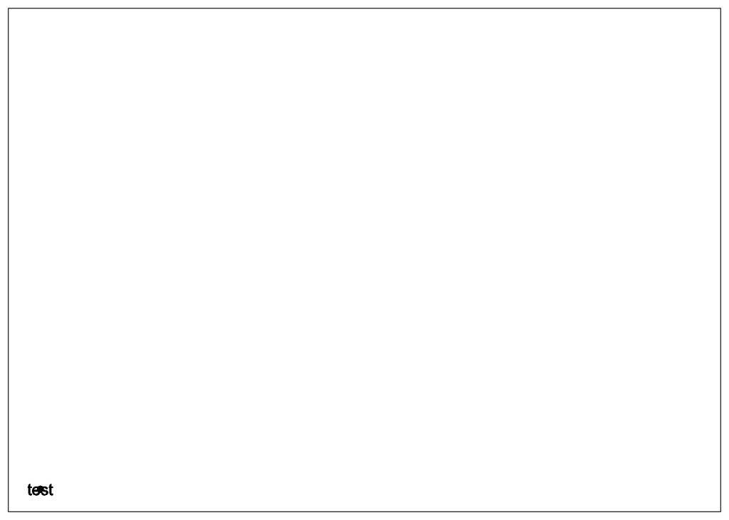

```r
ggplot(murders) +
    geom_point(x = 0, y = 0) +
    geom_text(x = 0, y = 0, label = "test")
```

You can see all the types of geoms in the [cheat sheet](https://github.com/rstudio/cheatsheets/blob/master/data-visualization-2.1.pdf). We will go over this more detail below.

15. Encodings: In ggplot2, we use `aes()` to implement the graphical encoding. `aes()` stands for aesthetic mapping, which is a synonym for graphical encoding. Analyzing the original graph, we recognize these specific encodings,
- State Population → x-axis coordinate
- Number of murders → y-axis coordinate
- Geographical region → color

Formalizing this with code,

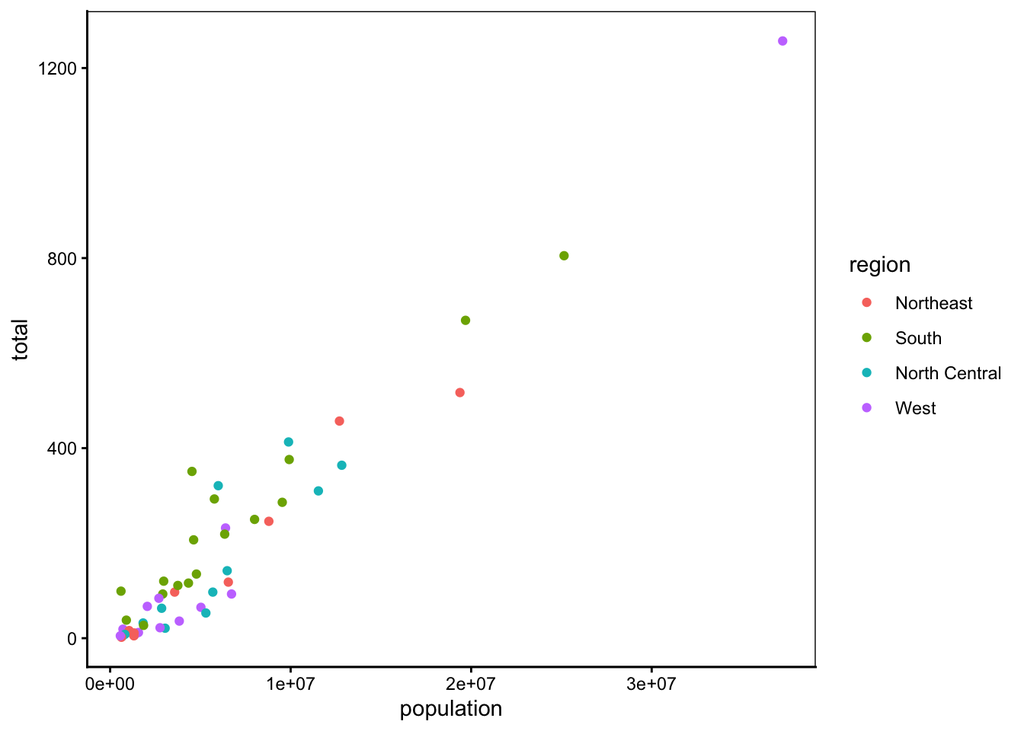

```r
ggplot(murders) +
    geom_point(aes(x = population, y = total, col = region))
```

16. The exact mappings from data values to visual channels are implemented through scales. For example, the original plot used log scales for population and total, it also used a custom color scale, set with `scale_color_brewer`.

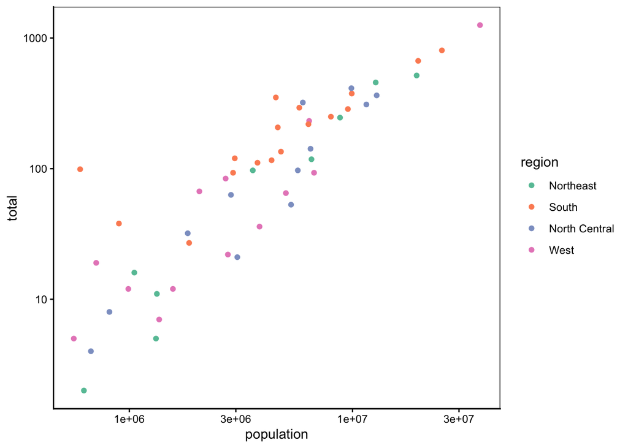

```r
ggplot(murders) +
    geom_point(aes(x = population, y = total, col = region)) +
    scale_color_brewer(palette = "Set2") +
    scale_x_log10() +
    scale_y_log10()
```

17. Notice that the original visualization also had text labeling all the states and a reference line giving the nationwide murder rate (so we could see whether a state was above or below the national rate given its population size). These are implemented simply by adding more layers. For the text labels, we used `geom_text_repel` from the `ggrepel` package,

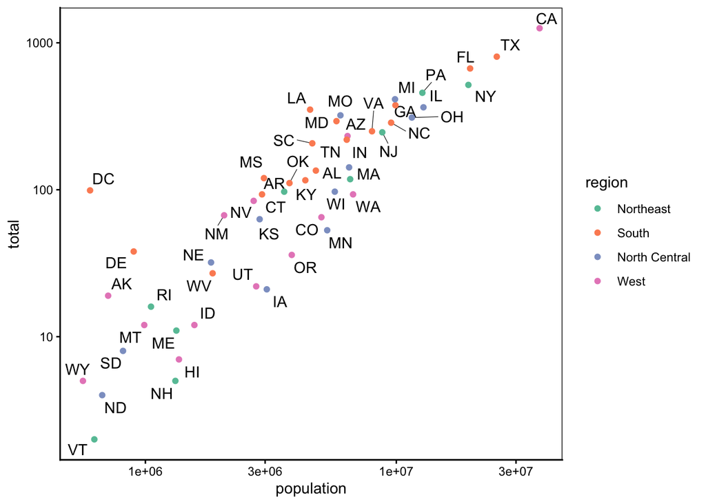

```r
ggplot(murders) +
    geom_text_repel(aes(x = population, y = total, label = abb), segment.size = 0.2) +
    geom_point(aes(x = population, y = total, col = region)) +
    scale_x_log10() +
    scale_y_log10() +
    scale_color_brewer(palette = "Set2")
```

This code is actually unnecessarily verbose. It copies x- and y-encoding for both the text and the point layers. A clearer approach is to set these encodings into a global aesthetic encoding, the second argument on the first line.

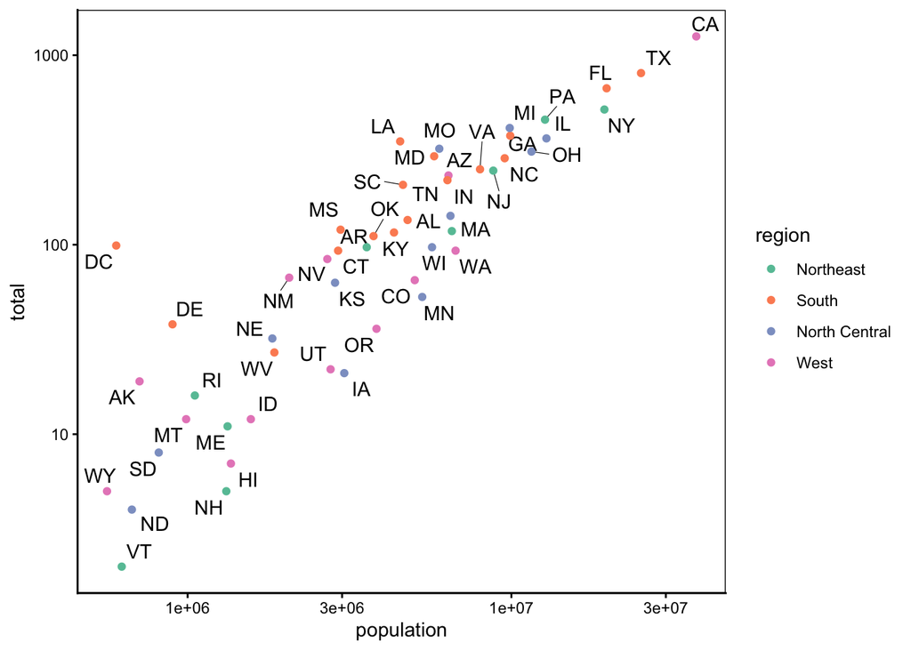

```r
ggplot(murders, aes(x = population, y = total)) +
    geom_text_repel(aes(label = abb), segment.size = 0.2) +
    geom_point(aes(col = region)) +
    scale_x_log10() +
    scale_y_log10() +
    scale_color_brewer(palette = "Set2")
```

18. The overlay line giving the national rate is actually a bit subtle to construct. Unlike all the other marks on this plot, it isn’t defined by any row in the murders data frame. It turns out that you can overlay marks by setting their properties directly. These layers no longer have `aes()`.

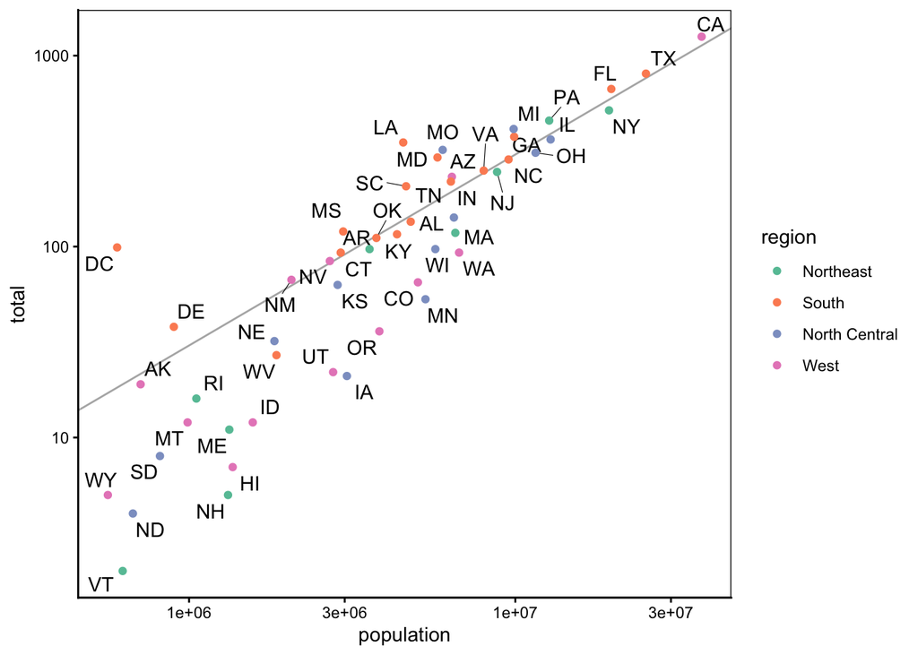

```r
r <- murders |>
    summarize(rate = sum(total) / sum(population)) |>
    pull(rate)

ggplot(murders, aes(x = population, y = total)) +
    geom_abline(intercept = log10(r), slope = 1, col = "#b3b3b3") +
    geom_text_repel(aes(label = abb), segment.size = 0.2) +
    geom_point(aes(col = region)) +
    scale_x_log10() +
    scale_y_log10() +
    scale_color_brewer(palette = "Set2")
```

19. Finally, we can customize the plot appearance and annotation. `theme()` fine tunes plot properties, like where to place the legend. `labs()` can be used to add better labels.

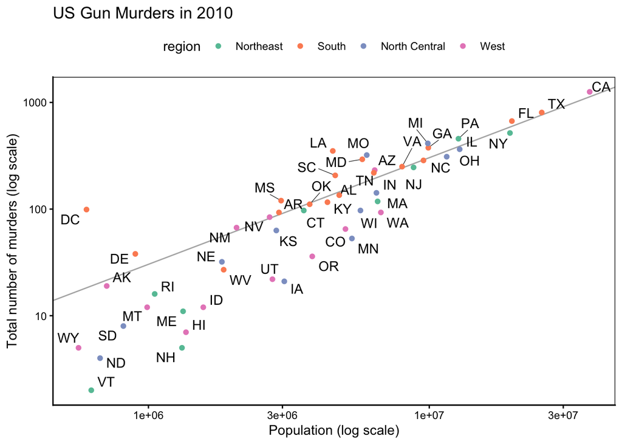

```r
ggplot(murders, aes(x = population, y = total)) +
    geom_abline(intercept = log10(r), slope = 1, col = "#b3b3b3") +
    geom_text_repel(aes(label = abb), segment.size = 0.2) +
    geom_point(aes(col = region)) +
    scale_x_log10() +
    scale_y_log10() +
    scale_color_brewer(palette = "Set2") +
    labs(
        x = "Population (log scale)",
        y = "Total number of murders (log scale)",
        color = "region",
        title = "US Gun Murders in 2010"
    ) +
    theme(legend.position = "top")
```

20. With agentic coding, you don’t need to manually write the layers. But you must still think carefully about your encodings. Even our simple plot above involved many subtle judgments. You might get lucky with a vague prompt, but to sharpen the quality of your thinking, you should iterate on the design and experiment with alternative specifications.

Here’s an example that built up the visualization above across several steps (link). One caution is that this is a common dataset, and the reasoning traces show that it referred to the book used in these notes. Even then, I made two manual changes. The rate line was drawn over the points, so I switched the layer order. I then lightened it “#d4d4d4” from “gray50”.

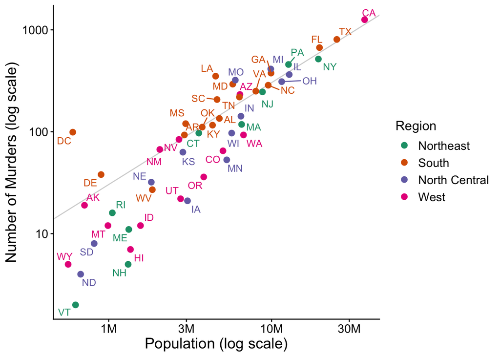

**Mosaic vgplot**

21. A similar grammar of graphics is implemented by Mosaic vgplot. One nuance is that this is done in javascript, rather than R, and requires a different data loading procedure. I’ve included the code below, but we won’t go over it. For now you can just copy and paste it for any visualization you want to make, and we’ll go over it in detail in our “Data Management” notes.

```r
# save R data frames to CSV
write_csv(murders, "data/murders.csv")
write_csv(gap2000, "data/gap2000.csv")
write_csv(gapminder, "data/gapminder.csv")
ojs_define(national_rate = national_rate)
```

```javascript
path = (p) => new URL(`data/${p}`, document.baseURI).href

// load CSVs to javascript
vg = {
  const vg = await import("https://cdn.jsdelivr.net/npm/@uwdata/vgplot@0.19.0/+esm");
  const wasm = await vg.wasmConnector();
  vg.coordinator().databaseConnector(wasm);
  await vg.coordinator().exec([
    vg.loadCSV("murders", path("murders.csv")),
    vg.loadCSV("gap2000", path("gap2000.csv")),
    vg.loadCSV("gapminder", path("gapminder.csv"))
  ]);
  return vg;
}
```

[interactive chart not shown]

```javascript
vg.plot(
  vg.dot(vg.from("murders"), {x: "population", y: "total", fill: "region", r: 5}),
  vg.width(650),
  vg.height(450)
)
```

[interactive chart not shown]

23. As before, we can customize the scales. Here, `xScale` and `yScale` allow us to use a log scale while the color scheme allows us to switch to the [Set 2 colorbrewer palette](https://emilhvitfeldt.github.io/r-color-palettes/discrete/RColorBrewer/Set2/).

```javascript
vg.plot(
  vg.dot(vg.from("murders"), {x: "population", y: "total", fill: "region", r: 5}),
  vg.xScale("log"),
  vg.yScale("log"),
  vg.colorScheme("set2"),
  vg.width(650),
  vg.height(450)
)
```

[interactive chart not shown]

In the spirit of the grammar of graphics, we can also compose layers. Here we’ve added state labels with `vg.text`. To avoid repeating the `x` and `y` specification, we defined a new object `xy`. The `...` notation means we “unpack” the entries so it can be merged with the parent object.

```javascript
xy = ({x: "population", y: "total"})

vg.plot(
  vg.dot(vg.from("murders"), {...xy, fill: "region", r: 5}),
  vg.text(vg.from("murders"), {...xy, text: "abb", dy: -12, fill: "#888", fontSize: 12}),
  vg.xScale("log"),
  vg.yScale("log"),
  vg.colorScheme("set2"),
  vg.width(650),
  vg.height(450)
)
```

[interactive chart not shown]

24. Finally, we overlay a line giving the national rate. The syntax here differs slightly from ggplot. Instead of specifying the intercept and slope, we specify the end points of the line in length two array. We’ve also added some annotation using `xLabel` and `yLabel` and a legend with `vg.colorLegend()`.

The reason why we’re using Mosaic to recreate a plot that we already is because it natively supports interactivity. The example below allows you to see state labels with a hover interaction. ggplot2 can create more beautiful figures and is easier to customize, but it renders static image files. We’ll go over the syntax during the interaction lectures.

```javascript
rate = national_rate / 1e5
rate_line = [
  {population: 1e5, total: rate * 1e5},
  {population: 4e7, total: rate * 4e7}
]

$hovered = vg.Selection.single({empty: true})

vg.plot(
  vg.line(rate_line, {x: "population", y: "total", stroke: "#d4d4d4"}),
  vg.dot(vg.from("murders"), {...xy, fill: "region", r: 5}),
  vg.nearest({as: $hovered}),
  vg.text(vg.from("murders", {filterBy: $hovered}), {...xy, text: "abb", dy: -12, fill: "#888", fontSize: 12}),
  vg.xScale("log"),
  vg.yScale("log"),
  vg.colorScheme("Set2"),
  vg.xLabel("Population (log scale)"),
  vg.yLabel("Number of Murders (log scale)"),
  vg.colorLegend({columns: 1}),
  vg.width(650),
  vg.height(450)
)
```

[interactive chart not shown]

### Graphical Marks

25. Depending on the data and problem at hand, it helps to have a wide vocabulary of potential graphical marks to apply. We’ve already seen *point* and **text marks**, though we’ve only used them to encode continuous $x, y$ position (and for the text, the associated label). They actually support encoding for even more visual channels – alpha, color, size, and shape (for points) – as documented in the ggplot2 [cheat sheet](https://rstudio.github.io/cheatsheets/data-visualization.pdf)[^2]. Let’s review a few of the other common marks and how to avoid potential pitfalls.
26. We’ll illustrate marks with the gapminder dataset, which describes the changes in standard of living around the world over the last few decades.

```r
gapminder <- read_csv("https://uwmadison.box.com/shared/static/dyz0qohqvgake2ghm4ngupbltkzpqb7t.csv", col_types = cols(cluster = "factor"))
gap2000 <- filter(gapminder, year == 2000) # keep only year 2000
```

27. **Bar Marks** associate a continuous field with a categorical one. They also support alpha, color (border of the bar), fill (inside of the bar), and linetype (e.g., solid vs dashed borders) visual channels.

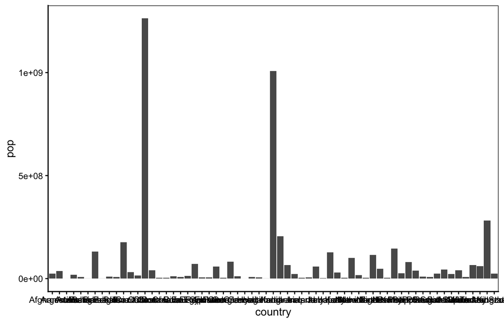

```r
ggplot(gap2000) +
    geom_col(aes(country, pop))
```

The plot above is messy – the country names are overlapping one another. One way to deal with this is to reverse the encodings.

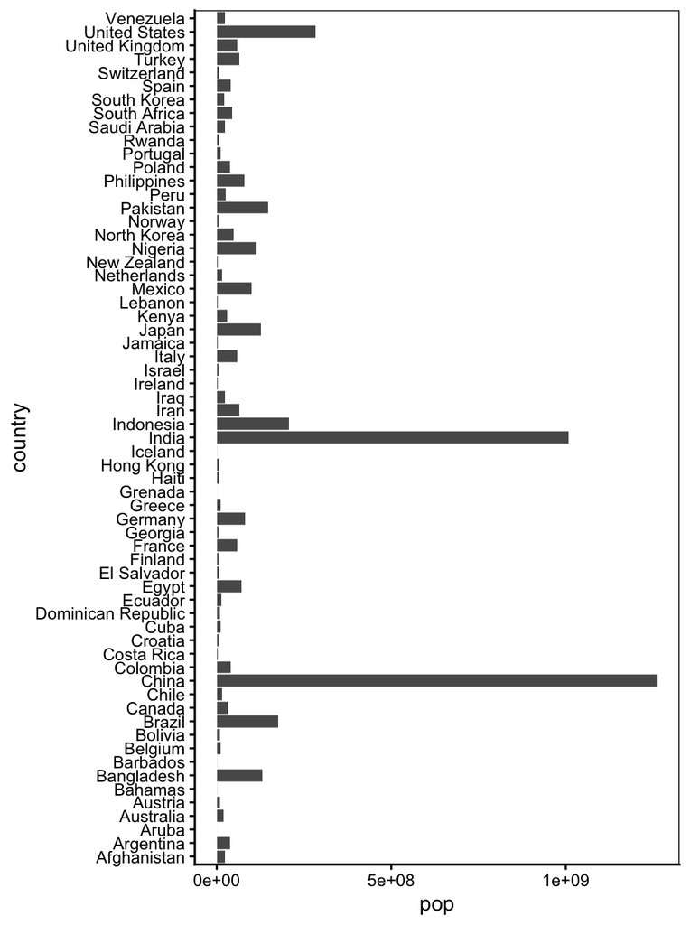

```r
ggplot(gap2000) +
    geom_col(aes(pop, country))
```

You could have instead rotated the labels,

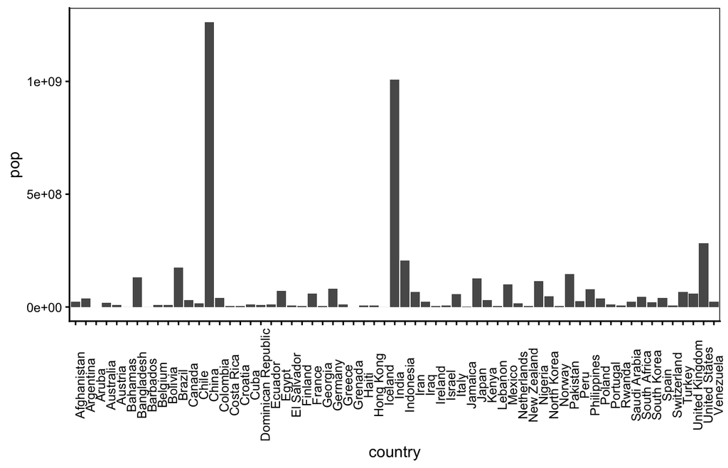

```r
ggplot(gap2000) +
    geom_col(aes(country, pop)) +
    theme(axis.text.x = element_text(angle = 90))
```

By default, the countries are ordered alphabetically. In some cases, this is justified. If we really don’t know what kinds of comparisons will be the most interesting, we should support alphabetical lookup. But for some tasks it helps to encode information in the variable order. For example, we can sort by country population.

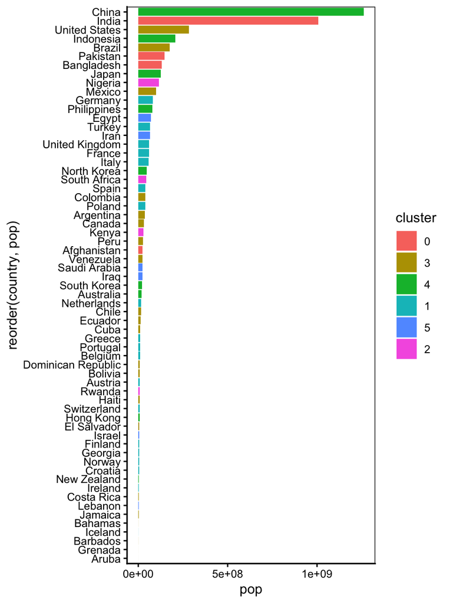

```r
ggplot(gap2000) +
    geom_col(aes(pop, reorder(country, pop), fill = cluster))
```

28. A few other points that I think are worth improving
    - The axis titles are not meaningful.
    - There is a strange gap between the left hand edge of the plot and the start of the bars.
    - The scientific notation for population size is unusual.
    - The color scheme is boring.

I’ve gone ahead and made these changes, putting comments next to which piece of code makes which modifications.

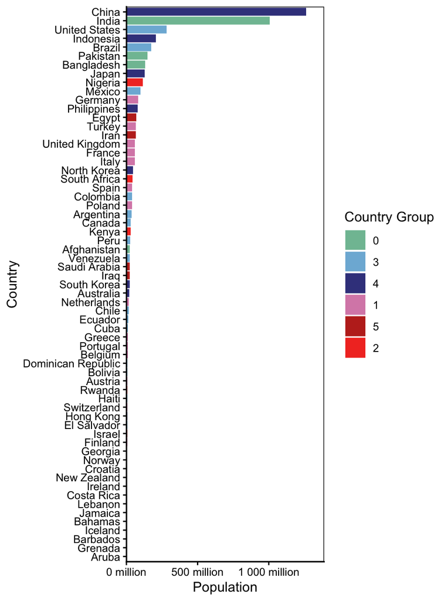

```r
ggplot(gap2000) +
    geom_col(
        aes(pop, reorder(country, pop), fill = cluster)
    ) +
    scale_x_continuous(labels = scales::unit_format(unit = "million", scale = 1e-6), expand = c(0, 0, 0.1, 0.1)) + # labels in millions, removes gap
    scale_fill_manual(values = c("#80BFA2", "#7EB6D9", "#3E428C", "#D98BB6", "#BF2E21", "#F23A29")) + # changes colors
    labs(x = "Population", y = "Country", fill = "Country Group", color = "Country Group") # adds labels
```

29. This seems like a lot of work for just a bar plot. But I think it’s amazing how customizable the figure is – we can give it our own sense of style. Ther eare still many things that could be interesting to experiment with, like font styles, background appearance, maybe splitting the countries into two panels.
30. In the plot above, each bar is anchored at 0. Instead, we could have each bar encode *two* continuous attributes, a left and right, along with a categorical attribute as in bar plots. This is called a **segment** mark. Let’s compare the minimum and maximum life expectancies within each country cluster. We’ll need to create a new `data.frame` with just the summary information. For this, we `group_by` each cluster, so that a `summarise` call finds the minimum and maximum life expectancies restricted to each cluster. We’ll discuss the `group_by` + `summarise` pattern next week.

```r
# find summary statistics
life_ranges <- gap2000 |>
    group_by(cluster) |>
    summarise(
        min_life = min(life_expect),
        max_life = max(life_expect)
    )

# look at a few rows
head(life_ranges)
```

```
# A tibble: 6 × 3
  cluster min_life max_life
  <fct>      <dbl>    <dbl>
1 0           42.1     63.6
2 3           58.1     79.8
3 4           66.7     82
4 1           70.5     80.6
5 5           57.0     79.7
6 2           43.4     53.4
```

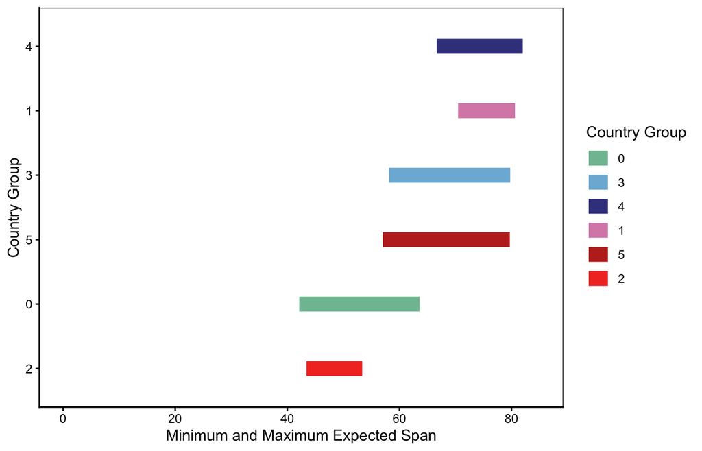

```r
ggplot(life_ranges) +
    geom_segment(
        aes(min_life, reorder(cluster, max_life), xend = max_life, yend = cluster, col = cluster),
        size = 5,
    ) +
    scale_color_manual(values = c("#80BFA2", "#7EB6D9", "#3E428C", "#D98BB6", "#BF2E21", "#F23A29")) +
    labs(x = "Minimum and Maximum Expected Span", col = "Country Group", y = "Country Group") +
    xlim(0, 85) # otherwise would only range from 42 to 82
```

31. **Line marks** are useful for comparing changes. Our eyes naturally focus on rates of change when we see lines. They support continuous `x` and `y` channels, as well as linetype and linewidth. Below, we’ll plot the fertility over time, colored in by country cluster.

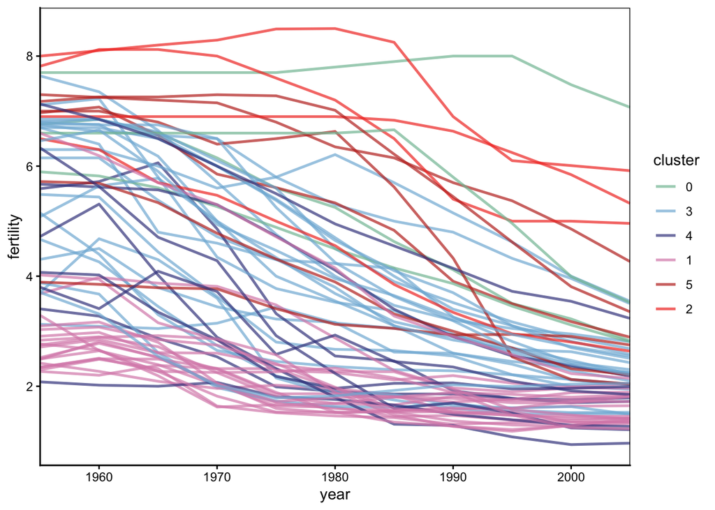

```r
ggplot(gapminder) +
    geom_line(
        aes(year, fertility, col = cluster, group = country),
        alpha = 0.7, size = 0.9
    ) +
    scale_x_continuous(expand = c(0, 0)) + # same trick of removing gap
    scale_color_manual(values = c("#80BFA2", "#7EB6D9", "#3E428C", "#D98BB6", "#BF2E21", "#F23A29"))
```

The `group` argument is necessary for ensuring each country gets its own line; if we removed it, `ggplot2` becomes confused by the fact that the same `x` (year) values are associated with multiple `y`’s (fertility rates). Please do not submit plots like this…

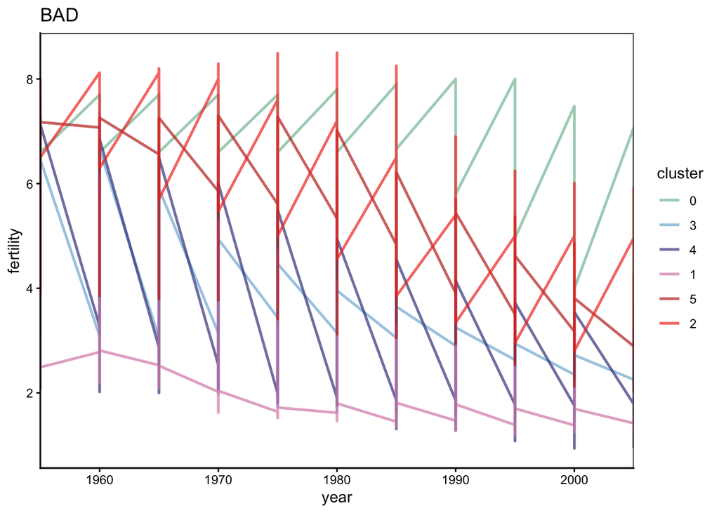

```r
ggplot(gapminder) +
    geom_line(
        aes(year, fertility, col = cluster),
        alpha = 0.7, size = 0.9
    ) +
    scale_x_continuous(expand = c(0, 0)) +
    labs(title = "BAD") +
    scale_color_manual(values = c("#80BFA2", "#7EB6D9", "#3E428C", "#D98BB6", "#BF2E21", "#F23A29"))
```

32. **Area marks** blend bar and line marks. The filled area supports absolute comparisons, while the changes in shape suggest derivatives.

```r
population_sums <- gapminder |>
    group_by(year, cluster) |>
    summarise(total_pop = sum(pop))
head(population_sums)
```

```
# A tibble: 6 × 3
# Groups:   year [1]
   year cluster total_pop
  <dbl> <fct>       <dbl>
1  1955 0       495927174
2  1955 3       355392405
3  1955 4       854125031
4  1955 1       360609771
5  1955 5        56064015
6  1955 2        60559800
```

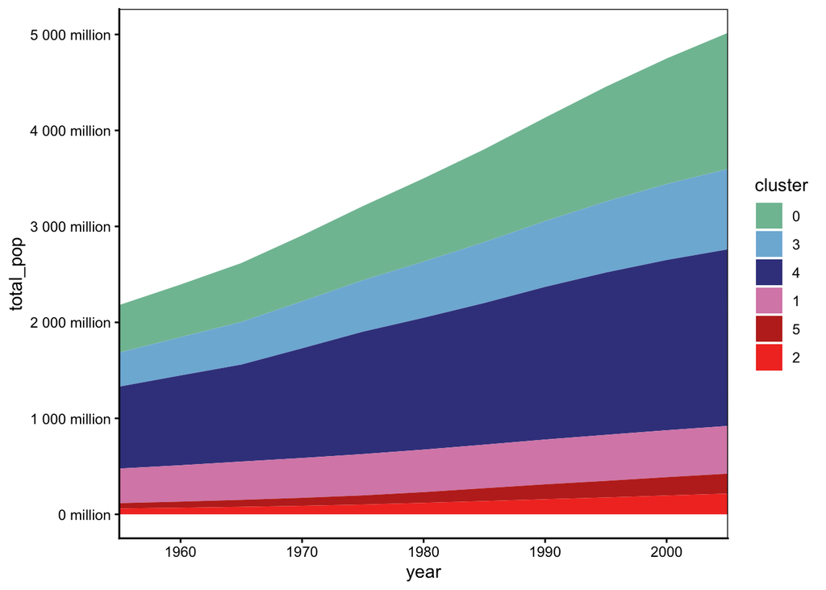

```r
ggplot(population_sums) +
    geom_area(aes(year, total_pop, fill = cluster)) +
    scale_y_continuous(labels = scales::unit_format(unit = "million", scale = 1e-6)) +
    scale_x_continuous(expand = c(0, 0)) +
    scale_fill_manual(values = c("#80BFA2", "#7EB6D9", "#3E428C", "#D98BB6", "#BF2E21", "#F23A29"))
```

Just like in bar marks, we don’t necessarily need to anchor the $y$-axis at 0. For example, here the bottom and top of each area mark is given by the 30% and 70% quantiles of population within each country cluster. This kind of mark is called a **ribbon mark**. It requires three continuous attributes.

```r
population_ranges <- gapminder |>
    group_by(year, cluster) |>
    summarise(min_pop = quantile(pop, 0.3), max_pop = quantile(pop, 0.7))
head(population_ranges)
```

```
# A tibble: 6 × 4
# Groups:   year [1]
   year cluster   min_pop   max_pop
  <dbl> <fct>       <dbl>     <dbl>
1  1955 0       40880121. 83941368.
2  1955 3        2221139   8671500
3  1955 4        9014491  61905422
4  1955 1        4532940  25990229.
5  1955 5        3007625  12316126.
6  1955 2        6600426. 17377594.
```

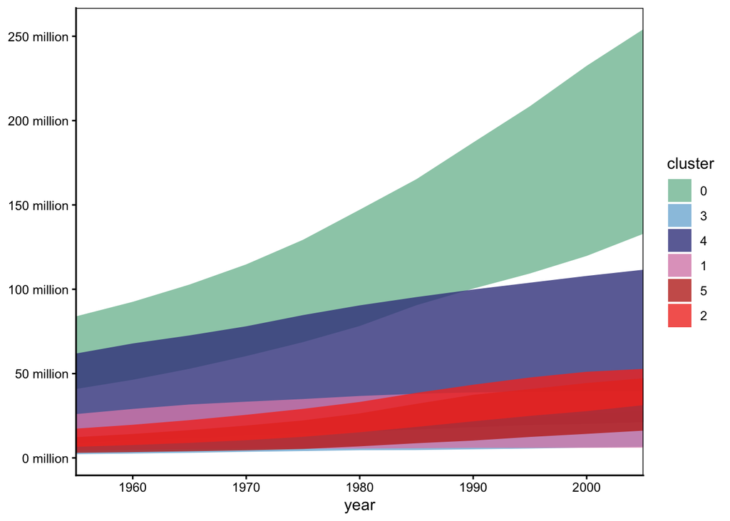

```r
ggplot(population_ranges) +
    geom_ribbon(
        aes(x = year, ymin = min_pop, ymax = max_pop, fill = cluster),
        alpha = 0.8
    ) +
    scale_y_continuous(labels = scales::unit_format(unit = "million", scale = 1e-6)) +
    scale_x_continuous(expand = c(0, 0)) +
    scale_fill_manual(values = c("#80BFA2", "#7EB6D9", "#3E428C", "#D98BB6", "#BF2E21", "#F23A29"))
```

33. All those examples were made with ggplot2. Mosaic doesn’t support segment or ribbon marks. But we can generate the analogous bar and line plots. FOr example, `barX` defines a bar mark, the `sort` option orders countries, and the remaining layers customize the annotation and scales.

```javascript
vg.plot(
  vg.barX(
    vg.from("gap2000"),
    {
      x: "pop",
      y: "country",
      fill: "cluster",
      sort: {y: "-x"}
    }
  ),
  vg.xLabel("Population"),
  vg.yLabel("Country"),
  vg.xTickFormat(d => `${d / 1e6} million`),
  vg.colorRange(["#80BFA2", "#7EB6D9", "#3E428C", "#D98BB6", "#BF2E21", "#F23A29"]),
  vg.colorLegend({label: "Country Group", columns: 1}),
  vg.marginLeft(120), // keep labels visible
  vg.width(400),
  vg.height(575)
)
```

[interactive chart not shown]

1.$^{\ast}$ A minor point on how to read the syntax for the argument in `xTickFormat`. In javascript, you can define an “anonymous” (unnamed) function using `x => what to do with x`. This is exactly like R’s `\(x) { what to do with x}`. The `${d / 1e6} million` substitutes the result of `d / 1e6` into the string “{result} million”, just like R’s `glue({result}, million)`.

34. Here is the analogous lineplot. The `z` encoding groups each country’s observations, and `stroke` is the mosaic equivalent of ggplot2’s `color`.

```javascript
vg.plot(
  vg.lineY(
    vg.from("gapminder"),
    {
      x: "year",
      y: "fertility",
      z: "country",
      stroke: "cluster",
      strokeOpacity: 0.7,
      strokeWidth: 2
    }
  ),
  vg.xTickFormat("d"), // makes sure years are formatted correctly
  vg.xLabel("Year"),
  vg.yLabel("Fertility"),
  vg.colorRange(["#80BFA2", "#7EB6D9", "#3E428C", "#D98BB6", "#BF2E21", "#F23A29"]),
  vg.colorLegend({label: "Country Group", columns: 1}),
  vg.width(500),
  vg.height(350)
)
```

[interactive chart not shown]

## Objectives

By the end of this week, you should be able to,

- Define the hierarchy of encodings, rank visual channels according to their perceptual efficiency, and use these concepts to evaluate visualizations (on their own, and in comparison with one another).
- Define graphical marks, visual encodings, and the grammar of graphics and discuss these concepts in the context of ggplot2 and mosaic vgplot code.
- Given a practical visualization goal, describe the graphical marks, graphical encodings, and scales that could be used to achieve them and justify your choices in terms of concepts like the hierarchy of encodings, popout, and the effectiveness principle.
- Recognize when an input data set or visualization task is/isn’t appropriate for a particular graphical mark, like point, line, bar, segment, text, or ribbon marks .
- Suggest improvements for a specific plot, justify the design choices, and outline the implementation in ggplot2 and mosaic.

## Footnotes

[^1]: If you didn’t make it to this lecture, the answer is that for both circles and bars the answer is seven. When we vote in class, the judgments are much more accurate for the bars than for the circles. Incidentally, when I’ve given this lecture to different audiences, the group that does this the best are the biologists, at one lab I went to (~ 20 people), everyone said either 7 or 8 for the bar chart.
[^2]: You’re responsible for knowing the encodings for the marks we discuss in this note, but not everything in the cheat sheet.